# Identification of Oncofetal piRNAs

Vanessa G. P. Souza

2025-02-28

## Introduction

# LUAD piRNA Analysis

### Load Libraries

```r
# Load necessary libraries
library(dplyr)
library(ggplot2)
library(readxl)
library(reshape2)
library(tibble)
library(pheatmap)
library(RColorBrewer)
library(tidyr)
library(DT)
library(knitr)
```

### Input dataset

```r
# Load the dataset
All_couns_LUAD_Michelle <- read_excel("All counts LUAD_Michelle.xlsx")

##datframe
All_couns_LUAD_Michelle <- as.data.frame(All_couns_LUAD_Michelle)

# Ensure the first column contains piRNA names and set them as row names
rownames(All_couns_LUAD_Michelle) <- All_couns_LUAD_Michelle$piRNAs
data2 <- All_couns_LUAD_Michelle

All_couns_LUAD_Michelle$piRNAs <- NULL  # Remove the first column after setting row names
rownames(All_couns_LUAD_Michelle) <- rownames(data2)
```

### These are the piRNA not expressed in ANL

```r
# Define the list of selected piRNAs
selected_piRNAs <- c("URS000000AA0C|piR-49039",
                     "URS000002DD41|piR-36026",
                     "URS00000508D0|piR-34021",
                     "URS0000066313|piR-38252",
                     "URS000006A033|piR-44717",
                     "URS000008666A|piR-45884",
                     "URS00000B383E|piR-44719",
                     "URS00000B8F4E|piR-33519",
                     "URS00000C8761|piR-35462",
                     "URS00000EDB82|piR-38574",
                     "URS000012A765|piR-41794",
                     "URS000013A1FE|piR-50446",
                     "URS000017EEB4|piR-33687",
                     "URS000019676E|piR-30259",
                     "URS00001ABE1D|piR-34804",
                     "URS00001CE783|piR-31703",
                     "URS00001DC20A|piR-36496",
                     "URS00001DCFCF|piR-50725",
                     "URS0000244976|piR-33534",
                     "URS00002FDE5F|piR-54888",
                     "URS000032C0C7|piR-34221",
                     "URS000033E13A|piR-49040",
                     "URS0000348F5F|piR-55706",
                     "URS00003905DB|piR-37183",
                     "URS00003A533D|piR-33686",
                     "URS00003B4A72|piR-37182",
                     "URS000040DC34|piR-35175",
                     "URS0000454FC3|piR-61135",
                     "URS0000459614|piR-33949",
                     "URS000048B6AB|piR-44715",
                     "URS00004A631E|piR-57145",
                     "URS00004E11B6|piR-31841",
                     "URS00004F3544|piR-58186",
                     "URS0000517230|piR-43452",
                     "URS0000526FBD|piR-30926",
                     "URS0000539EED|piR-36494",
                     "URS000054557D|piR-45883",
                     "URS000054DC1D|piR-35174",
                     "URS0000565C7F|piR-33685",
                     "URS000056FCD5|piR-34811",
                     "URS000060141E|piR-33054",
                     "URS0000613264|piR-50436",
                     "URS000061F7FC|piR-44716",
                     "URS00003097D9|piR-34420")

# Subset data to include only selected piRNAs
filtered_data <- All_couns_LUAD_Michelle[rownames(All_couns_LUAD_Michelle) %in% selected_piRNAs, ]

# Convert filtered data to a dataframe (if needed) and ensure rownames match selected piRNAs
filtered_data <- as.data.frame(filtered_data)
rownames(filtered_data) <- selected_piRNAs
```

### Define Sample Groups

```r
# Extract sample groups based on column names
fetal_samples <- grep("^Fetal_", colnames(All_couns_LUAD_Michelle), value = TRUE)
anl_samples <- grep("^ANL_", colnames(All_couns_LUAD_Michelle), value = TRUE)
tumor_samples <- grep("^Tumor_", colnames(All_couns_LUAD_Michelle), value = TRUE)

# Subset data to include only selected piRNAs
filtered_data <- All_couns_LUAD_Michelle[rownames(All_couns_LUAD_Michelle) %in% selected_piRNAs, ]

filtered_data <- as.data.frame(filtered_data)
rownames(filtered_data) <- selected_piRNAs

# Display the table (interactively within the R Markdown)
datatable(filtered_data, options = list(pageLength = 10))  # This will display the table
```

|  | Fetal_1 | Fetal_2 | Fetal_3 | Fetal_4 | Fetal_5 | Fetal_6 | Fetal_7 | Fetal_8 | Fetal_9 | Fetal_10 | Fetal_11 | Fetal_12 | Fetal_13 | Fetal_14 | Fetal_15 | Fetal_16 | Fetal_17 | Fetal_18 | Fetal_19 | Fetal_20 | Fetal_21 | Fetal_22 | Fetal_23 | Fetal_24 | Fetal_25 | ANL_1 | ANL_2 | ANL_3 | ANL_4 | … |
| --- | --- | --- | --- | --- | --- | --- | --- | --- | --- | --- | --- | --- | --- | --- | --- | --- | --- | --- | --- | --- | --- | --- | --- | --- | --- | --- | --- | --- | --- | --- |
| URS000000AA0C\|piR-49039 | 1.3418 | 0.662624 | 0.452482 | 0.839898 | 0.478177 | 2.1184 | 3.47681 | 2.03123 | 4.32722 | 1.55538 | 1.01295 | 0.818875 | 3.1293 | 5.14234 | 5.67047 | 3.56326 | 3.5048 | 3.48794 | 2.84912 | 5.09324 | 1.66293 | 2.74006 | 0.729688 | 6.40724 | 1.86659 | 0.234392 | 0.582922 | 0.640127 | 0 | … |
| URS000002DD41\|piR-36026 | 5.25538 | 0.120477 | 0.06464 | 43.1497 | 12.167 | 7.99695 | 20.0428 | 11.8667 | 44.354 | 68.091 | 1.17289 | 0.727889 | 8.55341 | 10.7318 | 39.1825 | 16.3646 | 37.1693 | 9.34769 | 34.6489 | 7.65673 | 3.51484 | 12.5466 | 1.59205 | 6.52165 | 17.9045 | 0 | 0 | 0.160032 | 0 | … |
| URS00000508D0\|piR-34021 | 0.260906 | 0.060239 | 0.193921 | 0.682417 | 1.59392 | 0.582559 | 0.920333 | 0.641442 | 0.973625 | 1.25294 | 0.106626 | 0 | 0.375516 | 0.279475 | 1.68582 | 0.659863 | 0.685149 | 0.837106 | 0.330865 | 1.31547 | 0.604703 | 1.29792 | 0.364844 | 0.68649 | 1.05609 | 0 | 0 | 0 | 0 | … |
| URS0000066313\|piR-38252 | 0.447267 | 2.89145 | 0.06464 | 0.524936 | 1.59392 | 0.476639 | 0.102259 | 0.213814 | 0.324542 | 0.25923 | 0.213253 | 0.090986 | 0.417239 | 0.279475 | 0.306512 | 0 | 0.97502 | 1.25566 | 1.21317 | 0.404761 | 0.453528 | 0.721067 | 0.066335 | 0.114415 | 1.49818 | 0 | 0 | 0 | 0 | … |
| URS000006A033\|piR-44717 | 1.22998 | 0.180716 | 1.03424 | 1.78478 | 2.86906 | 3.81312 | 6.34007 | 2.40541 | 4.38131 | 3.41319 | 0.799698 | 1.81972 | 4.17239 | 2.2358 | 8.63343 | 3.29931 | 2.37167 | 2.3718 | 1.783 | 4.01388 | 2.5322 | 3.31691 | 1.06136 | 2.63154 | 2.57883 | 0.234392 | 0.388615 | 0.160032 | 0.335644 | … |
| URS000008666A\|piR-45884 | 4.36085 | 0.481908 | 0.581763 | 1.10237 | 1.96584 | 4.97823 | 6.54459 | 4.32973 | 8.384 | 2.24666 | 0.959638 | 1.54676 | 4.50619 | 3.80086 | 19.3614 | 226.861 | 269.488 | 45.3433 | 62.2394 | 138.901 | 213.12 | 247.47 | 37.3136 | 150.456 | 20.6307 | 0 | 0 | 0.160032 | 0 | … |
| URS00000B383E\|piR-44719 | 15.6171 | 1.20477 | 2.58561 | 11.6536 | 13.6546 | 9.69167 | 12.5779 | 7.16277 | 13.0899 | 22.769 | 4.74488 | 9.46255 | 8.55341 | 9.94931 | 27.8415 | 83.0107 | 42.1367 | 38.0883 | 35.8805 | 45.5356 | 46.7889 | 40.524 | 20.9288 | 15.7893 | 22.7183 | 0.703177 | 0.77723 | 0 | 0 | … |
| URS00000B8F4E\|piR-33519 | 0.372722 | 3.37336 | 0 | 0.262468 | 0.371916 | 5.87855 | 17.2818 | 10.3165 | 12.008 | 1.55538 | 7.94367 | 3.9124 | 22.3223 | 26.8855 | 7.30521 | 43.6829 | 11.7266 | 4.7436 | 38.7664 | 48.1666 | 22.4496 | 3.74955 | 6.60036 | 33.7524 | 6.21376 | 0 | 0.388615 | 0.160032 | 0.335644 | … |
| URS00000C8761\|piR-35462 | 2.34815 | 0.180716 | 0.06464 | 1.99476 | 2.0721 | 2.648 | 4.29489 | 2.19159 | 5.0304 | 1.81461 | 3.19879 | 0.45493 | 3.62998 | 4.30391 | 3.57598 | 13.3292 | 14.7307 | 5.16216 | 22.6826 | 9.27578 | 7.4832 | 7.35489 | 0.729688 | 21.51 | 9.97149 | 1.17196 | 1.74877 | 0.320064 | 1.00693 | … |
| URS00000EDB82\|piR-38574 | 0.223633 | 3.61431 | 0.517122 | 0.57743 | 0.637569 | 0.37072 | 0.204519 | 0.374174 | 0.811354 | 0.302435 | 0.586446 | 3.9124 | 0.292068 | 1.062 | 1.3793 | 0.263945 | 0.777381 | 0.837106 | 1.47051 | 0.13492 | 0.18897 | 1.29792 | 0 | 0.114415 | 0.171922 | 0.468785 | 0.194307 | 0 | 0 | … |

[output cut: 34 more lines]

### Wilcoxon Test and Fold Change Calculation

```r
# Function to perform Wilcoxon test and compute fold change
perform_wilcoxon <- function(df, group1, group2, paired = FALSE) {
  results <- t(apply(df, 1, function(x) {
    group1_values <- as.numeric(x[group1])
    group2_values <- as.numeric(x[group2])

    test <- wilcox.test(group1_values, group2_values, paired = paired)
    fc <- mean(group1_values) / mean(group2_values)

    return(c(p_value = test$p.value, fc = fc))
  }))

  results <- as.data.frame(results)
  colnames(results) <- c("p_value", "fc")
  results$adjusted_p_value <- p.adjust(results$p_value, method = "BH")
  rownames(results) <- rownames(df)  # Ensure row names (piRNAs) are kept

  return(results)
}

# Perform differential expression analysis
tumor_vs_anl <- perform_wilcoxon(filtered_data, tumor_samples, anl_samples, paired = T)
fetal_vs_anl <- perform_wilcoxon(filtered_data, fetal_samples, anl_samples, paired = FALSE)

# Convert rownames to a column (if not already)
tumor_vs_anl <- tumor_vs_anl %>%
  tibble::rownames_to_column(var = "piRNA")

fetal_vs_anl <- fetal_vs_anl %>%
  tibble::rownames_to_column(var = "piRNA")

# Create a new column to mark differentially expressed piRNAs
tumor_vs_anl <- tumor_vs_anl %>%
  mutate(Differentially_Expressed = ifelse(adjusted_p_value < 0.05 & fc > 2, "Yes", "No"))

fetal_vs_anl <- fetal_vs_anl %>%
  mutate(Differentially_Expressed = ifelse(adjusted_p_value < 0.05 & fc > 2, "Yes", "No"))
```

### Tumor vs. ANL

```r
# Display the table (interactively within the R Markdown)
datatable(tumor_vs_anl, options = list(pageLength = 10))  # This will display the table
```

|  | piRNA | p_value | fc | adjusted_p_value | Differentially_Expressed |
| --- | --- | --- | --- | --- | --- |
| 1 | URS000000AA0C\|piR-49039 | 1.431920539277566e-06 | 6.629443668261588 | 2.423250143392803e-06 | Yes |
| 2 | URS000002DD41\|piR-36026 | 1.072110108405931e-07 | 8.954105696167177 | 4.717284476986098e-07 | Yes |
| 3 | URS00000508D0\|piR-34021 | 1.698294037362151e-05 | 4.803001205504922 | 2.264392049816201e-05 | Yes |
| 4 | URS0000066313\|piR-38252 | 2.132496838567456e-07 | 3.153410346088823 | 6.255324059797869e-07 | Yes |
| 5 | URS000006A033\|piR-44717 | 4.029632520996528e-07 | 3.826474644044002 | 9.372753994590594e-07 | Yes |
| 6 | URS000008666A\|piR-45884 | 8.195378884440722e-07 | 5.220374112598885 | 1.567811612675616e-06 | Yes |
| 7 | URS00000B383E\|piR-44719 | 2.842170943040399e-14 | 11.42903250799082 | 1.250555214937776e-12 | Yes |
| 8 | URS00000B8F4E\|piR-33519 | 3.604089101827412e-06 | 2.917618228098973 | 5.468273120014004e-06 | Yes |
| 9 | URS00000C8761\|piR-35462 | 1.269961558136856e-08 | 6.091814211406017 | 7.982615508288809e-08 | Yes |
| 10 | URS00000EDB82\|piR-38574 | 2.295446961397829e-07 | 3.04714167335165 | 6.312479143844029e-07 | Yes |

[output cut: 34 more lines]

### Fetal vs. ANL

```r
# Display the table (interactively within the R Markdown)
datatable(fetal_vs_anl, options = list(pageLength = 10))  # This will display the table
```

|  | piRNA | p_value | fc | adjusted_p_value | Differentially_Expressed |
| --- | --- | --- | --- | --- | --- |
| 1 | URS000000AA0C\|piR-49039 | 2.000493836355475e-12 | 23.02827860280921 | 3.689176451934757e-11 | Yes |
| 2 | URS000002DD41\|piR-36026 | 4.715843134578892e-11 | 80.23310118554292 | 1.220571164243949e-10 | Yes |
| 3 | URS00000508D0\|piR-34021 | 2.459161910999162e-09 | 8.346440786362532 | 3.731142209791832e-09 | Yes |
| 4 | URS0000066313\|piR-38252 | 0.01398678054817157 | 2.171224033286025 | 0.01431205451440811 | Yes |
| 5 | URS000006A033\|piR-44717 | 3.696544374644672e-11 | 10.84529487905026 | 1.084319683229104e-10 | Yes |
| 6 | URS000008666A\|piR-45884 | 1.13699033223422e-11 | 288.1019577855421 | 4.676694247088349e-11 | Yes |
| 7 | URS00000B383E\|piR-44719 | 5.898852007220344e-12 | 51.09172587476056 | 3.707849833109931e-11 | Yes |
| 8 | URS00000B8F4E\|piR-33519 | 8.606257315758676e-09 | 44.69404934922124 | 1.221533296430264e-08 | Yes |
| 9 | URS00000C8761\|piR-35462 | 1.44939064025224e-09 | 19.9471173796089 | 2.27761386325352e-09 | Yes |
| 10 | URS00000EDB82\|piR-38574 | 0.005559116430370062 | 2.176753832193334 | 0.006043204784133129 | Yes |

[output cut: 34 more lines]

### Show the piRNAs that are differentially expressed in both

```r
common_piRNAs <- inner_join(
  tumor_vs_anl %>% filter(Differentially_Expressed == "Yes"),
  fetal_vs_anl %>% filter(Differentially_Expressed == "Yes"),
  by = "piRNA"
)

# Display the table interactively
datatable(common_piRNAs, options = list(pageLength = 10))
```

|  | piRNA | p_value.x | fc.x | adjusted_p_value.x | Differentially_Expressed.x | p_value.y | fc.y | adjusted_p_value.y | Differentially_Expressed.y |
| --- | --- | --- | --- | --- | --- | --- | --- | --- | --- |
| 1 | URS000000AA0C\|piR-49039 | 1.431920539277566e-06 | 6.629443668261588 | 2.423250143392803e-06 | Yes | 2.000493836355475e-12 | 23.02827860280921 | 3.689176451934757e-11 | Yes |
| 2 | URS000002DD41\|piR-36026 | 1.072110108405931e-07 | 8.954105696167177 | 4.717284476986098e-07 | Yes | 4.715843134578892e-11 | 80.23310118554292 | 1.220571164243949e-10 | Yes |
| 3 | URS00000508D0\|piR-34021 | 1.698294037362151e-05 | 4.803001205504922 | 2.264392049816201e-05 | Yes | 2.459161910999162e-09 | 8.346440786362532 | 3.731142209791832e-09 | Yes |
| 4 | URS0000066313\|piR-38252 | 2.132496838567456e-07 | 3.153410346088823 | 6.255324059797869e-07 | Yes | 0.01398678054817157 | 2.171224033286025 | 0.01431205451440811 | Yes |
| 5 | URS000006A033\|piR-44717 | 4.029632520996528e-07 | 3.826474644044002 | 9.372753994590594e-07 | Yes | 3.696544374644672e-11 | 10.84529487905026 | 1.084319683229104e-10 | Yes |
| 6 | URS000008666A\|piR-45884 | 8.195378884440722e-07 | 5.220374112598885 | 1.567811612675616e-06 | Yes | 1.13699033223422e-11 | 288.1019577855421 | 4.676694247088349e-11 | Yes |
| 7 | URS00000B383E\|piR-44719 | 2.842170943040399e-14 | 11.42903250799082 | 1.250555214937776e-12 | Yes | 5.898852007220344e-12 | 51.09172587476056 | 3.707849833109931e-11 | Yes |
| 8 | URS00000B8F4E\|piR-33519 | 3.604089101827412e-06 | 2.917618228098973 | 5.468273120014004e-06 | Yes | 8.606257315758676e-09 | 44.69404934922124 | 1.221533296430264e-08 | Yes |
| 9 | URS00000C8761\|piR-35462 | 1.269961558136856e-08 | 6.091814211406017 | 7.982615508288809e-08 | Yes | 1.44939064025224e-09 | 19.9471173796089 | 2.27761386325352e-09 | Yes |
| 10 | URS00000EDB82\|piR-38574 | 2.295446961397829e-07 | 3.04714167335165 | 6.312479143844029e-07 | Yes | 0.005559116430370062 | 2.176753832193334 | 0.006043204784133129 | Yes |

[output cut: 27 more lines]

### List of Oncofetal piRNAs in LUAD

```r
# Extract only the piRNA names
piRNA_names <- common_piRNAs$piRNA

# Create a markdown-style bullet list
piRNA_list <- paste("- ", piRNA_names, collapse = "\n")

# Print it so R Markdown renders it as a proper list
cat(piRNA_list)
```

```
## -  URS000000AA0C|piR-49039
## -  URS000002DD41|piR-36026
## -  URS00000508D0|piR-34021
## -  URS0000066313|piR-38252
## -  URS000006A033|piR-44717
## -  URS000008666A|piR-45884
## -  URS00000B383E|piR-44719
## -  URS00000B8F4E|piR-33519
## -  URS00000C8761|piR-35462
## -  URS00000EDB82|piR-38574
## -  URS000012A765|piR-41794
## -  URS000013A1FE|piR-50446
## -  URS000017EEB4|piR-33687
## -  URS00001ABE1D|piR-34804
## -  URS00001DC20A|piR-36496
## -  URS00001DCFCF|piR-50725
## -  URS0000244976|piR-33534
## -  URS00002FDE5F|piR-54888
## -  URS000033E13A|piR-49040
## -  URS0000348F5F|piR-55706
## -  URS00003905DB|piR-37183
## -  URS00003A533D|piR-33686
## -  URS000040DC34|piR-35175
## -  URS0000454FC3|piR-61135
## -  URS0000459614|piR-33949
## -  URS000048B6AB|piR-44715
## -  URS00004F3544|piR-58186
## -  URS0000517230|piR-43452
## -  URS0000526FBD|piR-30926
## -  URS0000539EED|piR-36494
## -  URS000054557D|piR-45883
## -  URS000054DC1D|piR-35174
## -  URS0000565C7F|piR-33685
## -  URS000056FCD5|piR-34811
## -  URS000060141E|piR-33054
## -  URS0000613264|piR-50436
## -  URS000061F7FC|piR-44716
```

### Save Results to Files

```r
### Save results to text files
write.table(tumor_vs_anl, "piRNA_DE_LUAD_Tumor_vs_ANL.txt", sep = "\t", quote = FALSE, row.names = FALSE)
write.table(fetal_vs_anl, "piRNA_DE_LUAD_Fetal_vs_ANL.txt", sep = "\t", quote = FALSE, row.names = FALSE)
```

### Visualization: Boxplot of Top Differentially Expressed (in Tumor vs ANL) oncofetalpiRNAs

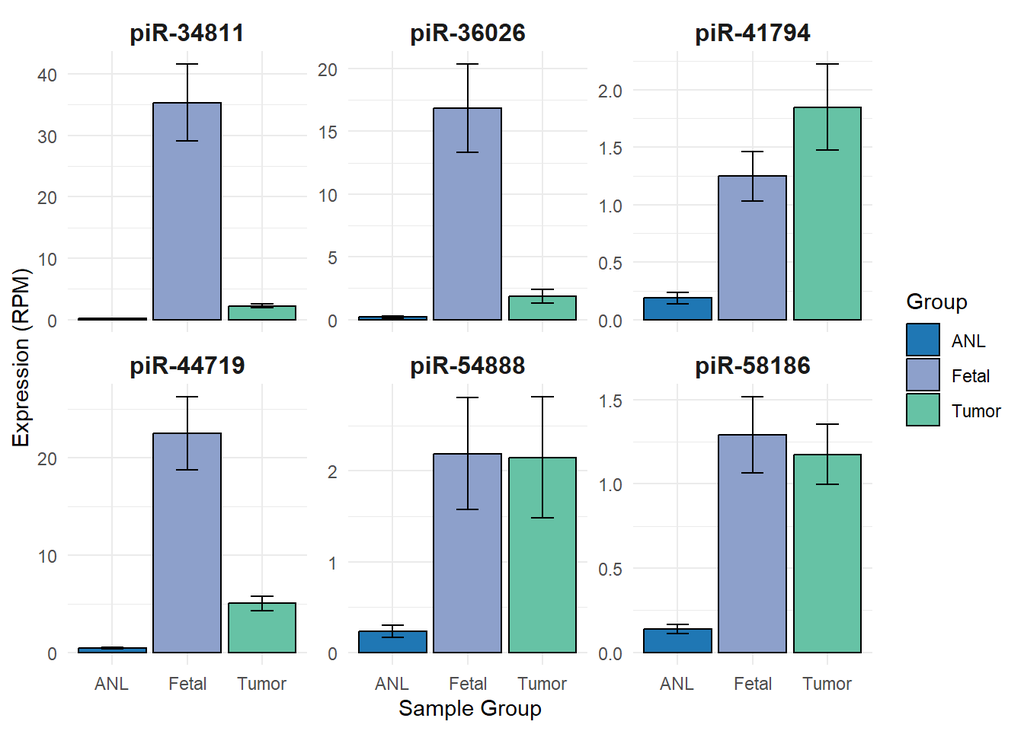

```r
# Define selected piRNAs for plotting
# List of selected piRNAs
selected_piRNAs <- c("piR-44719",
                     "piR-34811",
                     "piR-41794",
                     "piR-54888",
                     "piR-36026",
                     "piR-58186")


# Define y-axis limits for each piRNA
y_limits <- list(
  "piR-44719" = c(0, 40),
  "piR-34811" = c(0, 50),
  "piR-41794" = c(0, 5),
  "piR-54888" = c(0, 15),
  "piR-36026" = c(0, 50)
)

# Convert rownames to a column
All_couns_LUAD_Michelle_new <- tibble::rownames_to_column(All_couns_LUAD_Michelle, var = "piRNA")

# Define color scheme
group_colors <- c("ANL" = "#1f77b4", "Tumor" = "#66c2a5", "Fetal" = "#8da0cb")

# Reshape data from wide to long format
long_data <- melt(All_couns_LUAD_Michelle_new, id.vars = "piRNA", variable.name = "Sample", value.name = "Expression")

# Extract sample group information
long_data <- long_data %>%
  mutate(Group = case_when(
    grepl("^Fetal_", Sample) ~ "Fetal",
    grepl("^ANL_", Sample) ~ "ANL",
    grepl("^Tumor_", Sample) ~ "Tumor",
    TRUE ~ "Other"
  ))

# Remove everything before and including "|"
long_data$piRNA <- sub(".*\\|", "", long_data$piRNA)

# Create a combined bar plot with facets
p <- ggplot(long_data %>% filter(piRNA %in% selected_piRNAs), aes(x = Group, y = Expression, fill = Group)) +
  stat_summary(fun = mean, geom = "bar", position = "dodge", color = "black") +  # Bar plot with mean values
  stat_summary(fun.data = mean_se, geom = "errorbar", width = 0.3, position = position_dodge(0.9)) +  # Error bars (SE)
  theme_minimal() +
  labs(x = "Sample Group", y = "Expression (RPM)") +
  scale_fill_manual(values = group_colors) +
  facet_wrap(~ piRNA, scales = "free_y") +  # Separate facets, independent y-axis limits
  theme(
    plot.title = element_text(size = 14, face = "bold"),
    strip.text = element_text(size = 12, face = "bold")  # Adjust facet labels
  )

## view
p
```

# Identification of oncofetal piRNAs in TCGA-LUSC

This analysis involves differential gene expression (DGE) analysis using RNA-Seq data from TCGA-LUSC samples and lung fetal samples. The data were processed to analyze piRNA expression in normal lung tissue (ANL) and tumor samples. We used Wilcoxon tests to determine significant piRNA expression differences between groups. Differential expression of piRNAs was evaluated using the Wilcoxon test for tumor vs. ANL (paired samples) and FL vs. ANL (unpaired samples). Fold change (FC) was calculated as the ratio of mean expression between groups. P-values were adjusted with the Benjamini-Hochberg correction (BH) to control the false discovery rate. piRNAs were considered differentially expressed if they had an adjusted p-value < 0.05 and FC > 2. Oncofetal piRNAs were defined as those that were non-expressed in ANL but overexpressed in both tumor and fetal lung samples (BH p < 0.05, FC > 2).

### Input dataset

```r
# Load the dataset
All_couns_LUSC_Michelle <- read_excel("All counts LUSC_Michelle.xlsx")

##datframe
All_couns_LUSC_Michelle <- as.data.frame(All_couns_LUSC_Michelle)

# Ensure the first column contains piRNA names and set them as row names
rownames(All_couns_LUSC_Michelle) <- All_couns_LUSC_Michelle$piRNAs
data3 <- All_couns_LUSC_Michelle

All_couns_LUSC_Michelle$piRNAs <- NULL  # Remove the first column after setting row names
rownames(All_couns_LUSC_Michelle) <- rownames(data3)
```

### These are the piRNA not expressed in ANL

```r
selected_piRNAs <- c("URS0000001B02|piR-34342",
                     "URS000003587D|piR-34789",
                     "URS000003B4AC|piR-33127",
                     "URS00000508D0|piR-34021",
                     "URS0000066313|piR-38252",
                     "URS0000067282|piR-32148",
                     "URS000007540B|piR-30112",
                     "URS00000EDB82|piR-38574",
                     "URS000011C1E6|piR-55151",
                     "URS000011FF8D|piR-34929",
                     "URS0000132D2E|piR-34341",
                     "URS000013A1FE|piR-50446",
                     "URS00001400D7|piR-38600",
                     "URS00001402CA|piR-33535",
                     "URS0000147617|piR-55660",
                     "URS00001744C5|piR-43176",
                     "URS00001ABE1D|piR-34804",
                     "URS00001DBE3D|piR-33437",
                     "URS00001DC20A|piR-36496",
                     "URS00001DCFCF|piR-50725",
                     "URS0000251E99|piR-34249",
                     "URS000026C516|piR-54626",
                     "URS0000281D7C|piR-58356",
                     "URS00002A521F|piR-58355",
                     "URS00002B6A6F|piR-36056",
                     "URS00002C8F87|piR-31520",
                     "URS00002FDE5F|piR-54888",
                     "URS000032C0C7|piR-34221",
                     "URS000033E13A|piR-49040",
                     "URS0000348F5F|piR-55706",
                     "URS000037961A|piR-30890",
                     "URS000040DC34|piR-35175",
                     "URS0000418A01|piR-55152",
                     "URS000042C7F5|piR-51309",
                     "URS000042EE02|piR-31080",
                     "URS00004359E4|piR-35953",
                     "URS000043B9A8|piR-55150",
                     "URS0000459614|piR-33949",
                     "URS00004A074B|piR-57947",
                     "URS00004A631E|piR-57145",
                     "URS00004CF29B|piR-33404",
                     "URS00004D79E4|piR-32571",
                     "URS00004E11B6|piR-31841",
                     "URS00004F3544|piR-58186",
                     "URS00004FF920|piR-36150",
                     "URS0000517230|piR-43452",
                     "URS000051F814|piR-34597",
                     "URS0000526FBD|piR-30926",
                     "URS0000539EED|piR-36494",
                     "URS000054DC1D|piR-35174",
                     "URS0000593A81|piR-41464",
                     "URS000060141E|piR-33054",
                     "URS0000613264|piR-50436")

# Subset data to include only selected piRNAs
filtered_data <- All_couns_LUSC_Michelle[rownames(All_couns_LUSC_Michelle) %in% selected_piRNAs, ]

# Convert filtered data to a dataframe (if needed) and ensure rownames match selected piRNAs
filtered_data <- as.data.frame(filtered_data)
rownames(filtered_data) <- selected_piRNAs
```

### Define Sample Groups

```r
fetal_samples <- grep("^Fetal_", colnames(All_couns_LUSC_Michelle), value = TRUE)
anl_samples <- grep("^ANL_", colnames(All_couns_LUSC_Michelle), value = TRUE)
tumor_samples <- grep("^Tumor_", colnames(All_couns_LUSC_Michelle), value = TRUE)

# Display the table (interactively within the R Markdown)
datatable(filtered_data, options = list(pageLength = 10))  # This will display the table
```

|  | Fetal_1 | Fetal_2 | Fetal_3 | Fetal_4 | Fetal_5 | Fetal_6 | Fetal_7 | Fetal_8 | Fetal_9 | Fetal_10 | Fetal_11 | Fetal_12 | Fetal_13 | Fetal_14 | Fetal_15 | Fetal_16 | Fetal_17 | Fetal_18 | Fetal_19 | Fetal_20 | Fetal_21 | Fetal_22 | Fetal_23 | Fetal_24 | Fetal_25 | ANL_1 | ANL_2 | ANL_3 | ANL_4 | … |
| --- | --- | --- | --- | --- | --- | --- | --- | --- | --- | --- | --- | --- | --- | --- | --- | --- | --- | --- | --- | --- | --- | --- | --- | --- | --- | --- | --- | --- | --- | --- |
| URS0000001B02\|piR-34342 | 0.037272 | 0.240954 | 0.258561 | 0.262468 | 2.44402 | 2.648 | 1.53389 | 1.01562 | 1.18999 | 0.950509 | 0.959638 | 0.272958 | 2.04447 | 1.62095 | 1.63473 | 2.37551 | 2.42437 | 52.5982 | 3.41894 | 2.22619 | 2.56999 | 9.95073 | 0.530682 | 1.14415 | 19.2307 | 2.13595 | 0.064546 | 0.171439 | 1.18199 | … |
| URS000003587D\|piR-34789 | 0.037272 | 0.240954 | 3.16737 | 0.104987 | 0.584439 | 2.27728 | 3.06778 | 1.4967 | 1.73089 | 0.08641 | 1.33283 | 1.18282 | 1.33517 | 2.45938 | 2.65644 | 2.9034 | 0.579742 | 2.65084 | 1.10288 | 2.83333 | 1.13382 | 1.58635 | 2.2554 | 2.2883 | 3.63493 | 0 | 0 | 0 | 0 | … |
| URS000003B4AC\|piR-33127 | 0 | 0 | 0 | 0.104987 | 0.053131 | 1.0592 | 0.818074 | 0.694895 | 1.18999 | 0.08641 | 0.15994 | 2.00169 | 0.667583 | 0.89432 | 0.76628 | 0.923808 | 1.14631 | 2.3718 | 1.93005 | 0.505951 | 0.793673 | 0.288427 | 0.265341 | 0.45766 | 0.319284 | 0.194177 | 0.064546 | 0.085719 | 0.337711 | … |
| URS00000508D0\|piR-34021 | 0.260906 | 0.060239 | 0.193921 | 0.682417 | 1.59392 | 0.582559 | 0.920333 | 0.641442 | 0.973625 | 1.25294 | 0.106626 | 0 | 0.375516 | 0.279475 | 1.68582 | 0.659863 | 0.685149 | 0.837106 | 0.330865 | 1.31547 | 0.604703 | 1.29792 | 0.364844 | 0.68649 | 1.05609 | 0.582531 | 0.064546 | 0.171439 | 0.675422 | … |
| URS0000066313\|piR-38252 | 0.447267 | 2.89145 | 0.06464 | 0.524936 | 1.59392 | 0.476639 | 0.102259 | 0.213814 | 0.324542 | 0.25923 | 0.213253 | 0.090986 | 0.417239 | 0.279475 | 0.306512 | 0 | 0.97502 | 1.25566 | 1.21317 | 0.404761 | 0.453528 | 0.721067 | 0.066335 | 0.114415 | 1.49818 | 0.388354 | 0.258183 | 0.085719 | 0 | … |
| URS0000067282\|piR-32148 | 0.447267 | 0.120477 | 3.03809 | 0.052494 | 0.743831 | 5.34895 | 4.29489 | 0.748349 | 2.05543 | 0.043205 | 1.91928 | 3.00254 | 3.42136 | 1.28558 | 1.22605 | 11.3496 | 2.17403 | 5.44119 | 2.169 | 6.17261 | 7.21865 | 3.46112 | 1.79105 | 5.94958 | 1.35082 | 0.582531 | 0.064546 | 0.257158 | 0.844277 | … |
| URS000007540B\|piR-30112 | 0.223633 | 0.180716 | 1.61601 | 1.99476 | 0.850093 | 6.46111 | 6.95363 | 2.45886 | 2.70451 | 1.03692 | 1.91928 | 2.27465 | 3.79688 | 2.2358 | 3.8314 | 11.2177 | 10.0401 | 22.0438 | 7.94076 | 9.98411 | 10.7335 | 12.835 | 5.07465 | 2.51713 | 1.52274 | 0.194177 | 0.258183 | 0.257158 | 0.337711 | … |
| URS00000EDB82\|piR-38574 | 0.223633 | 3.61431 | 0.517122 | 0.57743 | 0.637569 | 0.37072 | 0.204519 | 0.374174 | 0.811354 | 0.302435 | 0.586446 | 3.9124 | 0.292068 | 1.062 | 1.3793 | 0.263945 | 0.777381 | 0.837106 | 1.47051 | 0.13492 | 0.18897 | 1.29792 | 0 | 0.114415 | 0.171922 | 0.194177 | 0.903639 | 0.342877 | 0.506566 | … |
| URS000011C1E6\|piR-55151 | 0 | 0.060239 | 0 | 0.57743 | 0.478177 | 0.37072 | 0.511296 | 0.534535 | 0.649084 | 1.20974 | 0 | 0 | 0.417239 | 0.614845 | 1.63473 | 1.31973 | 3.62338 | 4.88312 | 3.29027 | 1.92262 | 0.793673 | 3.46112 | 0.13267 | 0.572075 | 2.21043 | 0.194177 | 0.129091 | 0.171439 | 0.675422 | … |
| URS000011FF8D\|piR-34929 | 0.857261 | 0.361431 | 0.129281 | 8.71394 | 5.47247 | 12.5515 | 19.8383 | 8.87328 | 14.3339 | 3.75883 | 3.57199 | 12.3741 | 5.50756 | 7.09866 | 15.581 | 3.03537 | 8.49848 | 7.67348 | 6.76435 | 2.76587 | 13.4924 | 38.0724 | 3.98011 | 3.77569 | 4.1507 | 0.388354 | 0.516365 | 0.171439 | 0.506566 | … |

[output cut: 43 more lines]

### Wilcoxon Test and Fold Change Calculation

```r
perform_wilcoxon <- function(df, group1, group2, paired = FALSE) {
  results <- t(apply(df, 1, function(x) {
    group1_values <- as.numeric(x[group1])
    group2_values <- as.numeric(x[group2])

    test <- wilcox.test(group1_values, group2_values, paired = paired)
    fc <- mean(group1_values) / mean(group2_values)

    return(c(p_value = test$p.value, fc = fc))
  }))

  results <- as.data.frame(results)
  colnames(results) <- c("p_value", "fc")
  results$adjusted_p_value <- p.adjust(results$p_value, method = "BH")
  rownames(results) <- rownames(df)  # Ensure row names (piRNAs) are kept

  return(results)
}

# Perform differential expression analysis
tumor_vs_anl <- perform_wilcoxon(filtered_data, tumor_samples, anl_samples, paired = T)
fetal_vs_anl <- perform_wilcoxon(filtered_data, fetal_samples, anl_samples, paired = FALSE)

# Convert rownames to a column (if not already)
tumor_vs_anl <- tumor_vs_anl %>%
  tibble::rownames_to_column(var = "piRNA")

fetal_vs_anl <- fetal_vs_anl %>%
  tibble::rownames_to_column(var = "piRNA")

# Create a new column to mark differentially expressed piRNAs
tumor_vs_anl <- tumor_vs_anl %>%
  mutate(Differentially_Expressed = ifelse(adjusted_p_value < 0.05 & fc > 2, "Yes", "No"))

fetal_vs_anl <- fetal_vs_anl %>%
  mutate(Differentially_Expressed = ifelse(adjusted_p_value < 0.05 & fc > 2, "Yes", "No"))
```

### Tumor vs. ANL

```r
# Display the table (interactively within the R Markdown)
datatable(tumor_vs_anl, options = list(pageLength = 10))  # This will display the table
```

|  | piRNA | p_value | fc | adjusted_p_value | Differentially_Expressed |
| --- | --- | --- | --- | --- | --- |
| 1 | URS0000001B02\|piR-34342 | 2.64164356167385e-06 | 3.492104948578895 | 3.333502589731286e-06 | Yes |
| 2 | URS000003587D\|piR-34789 | 8.159185930565971e-07 | 32.96580346601822 | 1.271873100941166e-06 | Yes |
| 3 | URS000003B4AC\|piR-33127 | 6.44649847811828e-07 | 4.648808996087548 | 1.088546458628448e-06 | Yes |
| 4 | URS00000508D0\|piR-34021 | 2.00287242707946e-07 | 6.636158968598148 | 4.615314723270061e-07 | Yes |
| 5 | URS0000066313\|piR-38252 | 8.543717626707815e-06 | 2.801557648893536 | 1.006260076034476e-05 | Yes |
| 6 | URS0000067282\|piR-32148 | 1.837444239855062e-08 | 7.526724843060228 | 6.49230298082122e-08 | Yes |
| 7 | URS000007540B\|piR-30112 | 6.111622383286895e-06 | 2.602252916811326 | 7.361726961686487e-06 | Yes |
| 8 | URS00000EDB82\|piR-38574 | 3.258535343775299e-07 | 2.792106082612789 | 6.378574346765623e-07 | Yes |
| 9 | URS000011C1E6\|piR-55151 | 1.043296487158068e-07 | 10.71328235263317 | 2.633081610446554e-07 | Yes |
| 10 | URS000011FF8D\|piR-34929 | 0.04322159139344604 | 7.796667432842511 | 0.04491655576181648 | Yes |

[output cut: 43 more lines]

### Fetal vs. ANL

```r
# Display the table (interactively within the R Markdown)
datatable(fetal_vs_anl, options = list(pageLength = 10))  # This will display the table
```

|  | piRNA | p_value | fc | adjusted_p_value | Differentially_Expressed |
| --- | --- | --- | --- | --- | --- |
| 1 | URS0000001B02\|piR-34342 | 9.375481253815247e-07 | 10.58466488438658 | 1.713450022248994e-06 | Yes |
| 2 | URS000003587D\|piR-34789 | 4.643256890290913e-13 | 84.70498889887403 | 6.15231537963546e-12 | Yes |
| 3 | URS000003B4AC\|piR-33127 | 1.108813264321748e-05 | 5.954187280117156 | 1.780821303304625e-05 | Yes |
| 4 | URS00000508D0\|piR-34021 | 5.489228494465181e-06 | 2.592872142981156 | 9.384810006666277e-06 | Yes |
| 5 | URS0000066313\|piR-38252 | 0.04005009573563039 | 2.244649227871458 | 0.04245310147976822 | Yes |
| 6 | URS0000067282\|piR-32148 | 5.641123050084261e-09 | 14.90949110765954 | 1.195918086617863e-08 | Yes |
| 7 | URS000007540B\|piR-30112 | 1.403959187401089e-09 | 15.78376042437132 | 3.720491846612884e-09 | Yes |
| 8 | URS00000EDB82\|piR-38574 | 0.2724927608430543 | 1.670692304601903 | 0.2777330062438823 | No |
| 9 | URS000011C1E6\|piR-55151 | 2.702333610602968e-05 | 7.836441293653117 | 3.978435593387704e-05 | Yes |
| 10 | URS000011FF8D\|piR-34929 | 1.130361087666299e-10 | 36.52077232061856 | 4.608395203562604e-10 | Yes |

[output cut: 43 more lines]

### Show the piRNAs that are differentially expressed in both

```r
common_piRNAs <- inner_join(
  tumor_vs_anl %>% filter(Differentially_Expressed == "Yes"),
  fetal_vs_anl %>% filter(Differentially_Expressed == "Yes"),
  by = "piRNA"
)

# Display the table interactively
datatable(common_piRNAs, options = list(pageLength = 10))
```

|  | piRNA | p_value.x | fc.x | adjusted_p_value.x | Differentially_Expressed.x | p_value.y | fc.y | adjusted_p_value.y | Differentially_Expressed.y |
| --- | --- | --- | --- | --- | --- | --- | --- | --- | --- |
| 1 | URS0000001B02\|piR-34342 | 2.64164356167385e-06 | 3.492104948578895 | 3.333502589731286e-06 | Yes | 9.375481253815247e-07 | 10.58466488438658 | 1.713450022248994e-06 | Yes |
| 2 | URS000003587D\|piR-34789 | 8.159185930565971e-07 | 32.96580346601822 | 1.271873100941166e-06 | Yes | 4.643256890290913e-13 | 84.70498889887403 | 6.15231537963546e-12 | Yes |
| 3 | URS000003B4AC\|piR-33127 | 6.44649847811828e-07 | 4.648808996087548 | 1.088546458628448e-06 | Yes | 1.108813264321748e-05 | 5.954187280117156 | 1.780821303304625e-05 | Yes |
| 4 | URS00000508D0\|piR-34021 | 2.00287242707946e-07 | 6.636158968598148 | 4.615314723270061e-07 | Yes | 5.489228494465181e-06 | 2.592872142981156 | 9.384810006666277e-06 | Yes |
| 5 | URS0000066313\|piR-38252 | 8.543717626707815e-06 | 2.801557648893536 | 1.006260076034476e-05 | Yes | 0.04005009573563039 | 2.244649227871458 | 0.04245310147976822 | Yes |
| 6 | URS0000067282\|piR-32148 | 1.837444239855062e-08 | 7.526724843060228 | 6.49230298082122e-08 | Yes | 5.641123050084261e-09 | 14.90949110765954 | 1.195918086617863e-08 | Yes |
| 7 | URS000007540B\|piR-30112 | 6.111622383286895e-06 | 2.602252916811326 | 7.361726961686487e-06 | Yes | 1.403959187401089e-09 | 15.78376042437132 | 3.720491846612884e-09 | Yes |
| 8 | URS000011C1E6\|piR-55151 | 1.043296487158068e-07 | 10.71328235263317 | 2.633081610446554e-07 | Yes | 2.702333610602968e-05 | 7.836441293653117 | 3.978435593387704e-05 | Yes |
| 9 | URS000011FF8D\|piR-34929 | 0.04322159139344604 | 7.796667432842511 | 0.04491655576181648 | Yes | 1.130361087666299e-10 | 36.52077232061856 | 4.608395203562604e-10 | Yes |
| 10 | URS0000132D2E\|piR-34341 | 4.306252206566811e-05 | 2.481978522888945 | 4.754820144750854e-05 | Yes | 0.0007325261959882529 | 3.518509655660069 | 0.0008627530752750535 | Yes |

[output cut: 36 more lines]

### List of Oncofetal piRNAs in LUSC

```r
# Extract only the piRNA names
piRNA_names <- common_piRNAs$piRNA

# Create a markdown-style bullet list
piRNA_list <- paste("- ", piRNA_names, collapse = "\n")

# Print it so R Markdown renders it as a proper list
cat(piRNA_list)
```

```
## -  URS0000001B02|piR-34342
## -  URS000003587D|piR-34789
## -  URS000003B4AC|piR-33127
## -  URS00000508D0|piR-34021
## -  URS0000066313|piR-38252
## -  URS0000067282|piR-32148
## -  URS000007540B|piR-30112
## -  URS000011C1E6|piR-55151
## -  URS000011FF8D|piR-34929
## -  URS0000132D2E|piR-34341
## -  URS000013A1FE|piR-50446
## -  URS00001400D7|piR-38600
## -  URS00001402CA|piR-33535
## -  URS0000147617|piR-55660
## -  URS00001744C5|piR-43176
## -  URS00001ABE1D|piR-34804
## -  URS00001DBE3D|piR-33437
## -  URS00001DC20A|piR-36496
## -  URS00001DCFCF|piR-50725
## -  URS0000251E99|piR-34249
## -  URS000026C516|piR-54626
## -  URS0000281D7C|piR-58356
## -  URS00002A521F|piR-58355
## -  URS00002B6A6F|piR-36056
## -  URS00002C8F87|piR-31520
## -  URS00002FDE5F|piR-54888
## -  URS000032C0C7|piR-34221
## -  URS000037961A|piR-30890
## -  URS000040DC34|piR-35175
## -  URS0000418A01|piR-55152
## -  URS000042C7F5|piR-51309
## -  URS000042EE02|piR-31080
## -  URS00004359E4|piR-35953
## -  URS000043B9A8|piR-55150
## -  URS00004A074B|piR-57947
## -  URS00004CF29B|piR-33404
## -  URS00004D79E4|piR-32571
## -  URS00004E11B6|piR-31841
## -  URS00004F3544|piR-58186
## -  URS00004FF920|piR-36150
## -  URS000051F814|piR-34597
## -  URS0000526FBD|piR-30926
## -  URS0000539EED|piR-36494
## -  URS000054DC1D|piR-35174
## -  URS0000593A81|piR-41464
## -  URS0000613264|piR-50436
```

### Save Results to Files

```r
### Save results to text files
write.table(tumor_vs_anl, "piRNA_DE_LUSC_Tumor_vs_ANL.txt", sep = "\t", quote = FALSE, row.names = FALSE)
write.table(fetal_vs_anl, "piRNA_DE_LUSC_Fetal_vs_ANL.txt", sep = "\t", quote = FALSE, row.names = FALSE)
```

### Visualization: Boxplot of Top Differentially Expressed oncofetalpiRNAs (top FC) (in Tumor vs ANL)

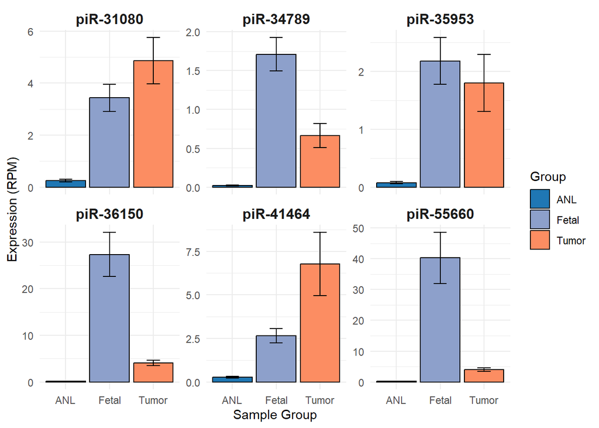

```r
# Define selected piRNAs for plotting
# List of selected piRNAs
selected_piRNAs <- c("piR-34789",
                     "piR-36150",
                     "piR-41464",
                     "piR-35953",
                     "piR-55660",
                     "piR-31080")


# Define y-axis limits for each piRNA
y_limits <- list(
  "piR-44719" = c(0, 40),
  "piR-34811" = c(0, 50),
  "piR-41794" = c(0, 50),
  "piR-54888" = c(0, 40),
  "piR-36026" = c(0, 50)
)

# Convert rownames to a column
All_couns_LUSC_Michelle_new <- tibble::rownames_to_column(All_couns_LUSC_Michelle, var = "piRNA")

# Define color scheme
group_colors <- c("ANL" = "#1f77b4", "Tumor" = "#fc8d62", "Fetal" = "#8da0cb")

# Reshape data from wide to long format
long_data <- melt(All_couns_LUSC_Michelle_new, id.vars = "piRNA", variable.name = "Sample", value.name = "Expression")

# Extract sample group information
long_data <- long_data %>%
  mutate(Group = case_when(
    grepl("^Fetal_", Sample) ~ "Fetal",
    grepl("^ANL_", Sample) ~ "ANL",
    grepl("^Tumor_", Sample) ~ "Tumor",
    TRUE ~ "Other"
  ))

# Remove everything before and including "|"
long_data$piRNA <- sub(".*\\|", "", long_data$piRNA)

# Create a combined bar plot with facets
p2 <- ggplot(long_data %>% filter(piRNA %in% selected_piRNAs), aes(x = Group, y = Expression, fill = Group)) +
  stat_summary(fun = mean, geom = "bar", position = "dodge", color = "black") +  # Bar plot with mean values
  stat_summary(fun.data = mean_se, geom = "errorbar", width = 0.3, position = position_dodge(0.9)) +  # Error bars (SE)
  theme_minimal() +
  labs(x = "Sample Group", y = "Expression (RPM)") +
  scale_fill_manual(values = group_colors) +
  facet_wrap(~ piRNA, scales = "free_y") +  # Separate facets, independent y-axis limits
  theme(
    plot.title = element_text(size = 14, face = "bold"),
    strip.text = element_text(size = 12, face = "bold")  # Adjust facet labels
  )

## view
p2
```

# Identification of oncofetal piRNAs in BCCA-LUAD

This analysis involves differential gene expression (DGE) analysis using RNA-Seq data from BCCA-LUAD samples and lung fetal samples. The data were processed to analyze piRNA expression in normal lung tissue (ANL) and tumor samples. We used Wilcoxon tests to determine significant piRNA expression differences between groups. Differential expression of piRNAs was evaluated using the Wilcoxon test for tumor vs. ANL (paired samples) and FL vs. ANL (unpaired samples). Fold change (FC) was calculated as the ratio of mean expression between groups. P-values were adjusted with the Benjamini-Hochberg correction (BH) to control the false discovery rate. piRNAs were considered differentially expressed if they had an adjusted p-value < 0.05 and FC > 2. Oncofetal piRNAs were defined as those that were non-expressed in ANL but overexpressed in both tumor and fetal lung samples (BH p < 0.05, FC > 2).

### Input dataset

```r
## piRNas EXCLUSIVE OF TUMORS AND FETAL BCCA Cohort
BCCA_LUAD_2024_forDEanalysis <- read_excel("BCCA_LUAD_2024_forDEanalysis.xlsx")
```

### Identify sample groups

```r
fetal_samples <- grep("^Fetal_", colnames(BCCA_LUAD_2024_forDEanalysis), value = TRUE)
tumor_samples <- grep("^Tumor_", colnames(BCCA_LUAD_2024_forDEanalysis), value = TRUE)
anl_samples <- grep("^ANL_", colnames(BCCA_LUAD_2024_forDEanalysis), value = TRUE)
```

### Function to find expressed piRNAs (RPM ≥ 1 in at least 10% of the samples in each group Tumor, ANL and Fetal)

```r
find_expressed <- function(df, sample_cols) {
  if (length(sample_cols) > 0) {
    min_samples <- ceiling(0.10 * length(sample_cols))  # 10% of samples, rounded up
    expressed <- df %>%
      filter(rowSums(.[, sample_cols] >= 1) >= min_samples) %>%
      pull(1)  # Get piRNA names
    return(expressed)
  } else {
    return(character(0))  # Return empty if no samples in group
  }
}

# Get expressed piRNAs in each group
expressed_fetal <- find_expressed(BCCA_LUAD_2024_forDEanalysis, fetal_samples)
expressed_tumor <- find_expressed(BCCA_LUAD_2024_forDEanalysis, tumor_samples)
expressed_anl <- find_expressed(BCCA_LUAD_2024_forDEanalysis, anl_samples)

# Create a named list
expressed_list <- list(
  "Fetal" = expressed_fetal,
  "Tumor" = expressed_tumor,
  "ANL" = expressed_anl
)

# Convert to a data frame for saving
expressed_df <- stack(expressed_list)

# Save as a .txt file
write.table(expressed_df, "piRNAs_expressed_in_BCCA.txt", row.names = FALSE, col.names = c("piRNA", "Group"), quote = FALSE, sep = "\t")
```

### Differential Gene Expression Analysis

```r
## import
All_couns_BCCA_Michelle <- BCCA_LUAD_2024_forDEanalysis

# Ensure the first column contains piRNA names and set them as row names
BCCA_LUAD_2024_forDEanalysis <- as.data.frame(BCCA_LUAD_2024_forDEanalysis) ## convert to a dataframe

rownames(BCCA_LUAD_2024_forDEanalysis) <- BCCA_LUAD_2024_forDEanalysis$piRNAs
data4 <- All_couns_BCCA_Michelle

All_couns_BCCA_Michelle$piRNAs <- NULL  # Remove the first column after setting row names
rownames(All_couns_BCCA_Michelle) <- data4$piRNAs
```

### piRNAs not expressed in ANL samples

```r
# Define the list of selected piRNAs ## those not expressed in ANL

selected_piRNAs <- c("URS000000AA0C|piR-49039",
                     "URS000003587D|piR-34789",
                     "URS000009C105|piR-36244",
                     "URS000013A1FE|piR-50446",
                     "URS0000281D7C|piR-58356",
                     "URS00002A521F|piR-58355",
                     "URS00002BC69D|piR-34984",
                     "URS000042C7F5|piR-51309",
                     "URS00004359E4|piR-35953",
                     "URS00004CF29B|piR-33404",
                     "URS00004F3544|piR-58186",
                     "URS00005DADAC|piR-36257",
                     "URS00005FF09B|piR-36229",
                     "URS000002D2B3|piR-33164",
                     "URS000002DD41|piR-36026",
                     "URS000006A033|piR-44717",
                     "URS000006D277|piR-34377",
                     "URS0000072763|piR-38183",
                     "URS000008666A|piR-45884",
                     "URS0000086DBC|piR-36711",
                     "URS00000B577C|piR-38184",
                     "URS00000B8F4E|piR-33519",
                     "URS00000B9DA1|piR-31701",
                     "URS00000C6189|piR-33879",
                     "URS00000E6438|piR-59259",
                     "URS000011FF8D|piR-34929",
                     "URS000013DB6B|piR-44892",
                     "URS0000144669|piR-43992",
                     "URS0000177262|piR-38182",
                     "URS00001DCFCF|piR-50725",
                     "URS00001FACBA|piR-57862",
                     "URS000020012B|piR-36706",
                     "URS000028B672|piR-33856",
                     "URS000029361F|piR-57861",
                     "URS00002B6A6F|piR-36056",
                     "URS00003097D9|piR-34420",
                     "URS00003197D7|piR-34291",
                     "URS0000337B2A|piR-35229",
                     "URS0000338622|piR-60238",
                     "URS00003491AD|piR-35466",
                     "URS00003494FE|piR-35407",
                     "URS00003C0FA7|piR-30840",
                     "URS00003D4535|piR-61298",
                     "URS00003E6FC6|piR-35414",
                     "URS0000402639|piR-35548",
                     "URS000040DC34|piR-35175",
                     "URS000042EE02|piR-31080",
                     "URS000044473B|piR-33520",
                     "URS00004570F0|piR-36258",
                     "URS000048B6AB|piR-44715",
                     "URS00004EB0AA|piR-34736",
                     "URS00004F59A9|piR-36705",
                     "URS0000526FBD|piR-30926",
                     "URS000054557D|piR-45883",
                     "URS000054C938|piR-36272",
                     "URS000054DC1D|piR-35174",
                     "URS000057BC8B|piR-30652",
                     "URS0000583064|piR-43997",
                     "URS000059B99C|piR-33864",
                     "URS00005C4FD3|piR-32374",
                     "URS00005F0138|piR-59260",
                     "URS000061F7FC|piR-44716",
                     "URS00001940C2|piR-36236",
                     "URS000021A073|piR-60758")

# Extract sample groups
fetal_samples <- grep("^Fetal_", colnames(All_couns_BCCA_Michelle), value = TRUE)
anl_samples <- grep("^ANL_", colnames(All_couns_BCCA_Michelle), value = TRUE)
tumor_samples <- grep("^Tumor_", colnames(All_couns_BCCA_Michelle), value = TRUE)

# Subset data to include only selected piRNAs
filtered_data <- All_couns_BCCA_Michelle[rownames(All_couns_BCCA_Michelle) %in% selected_piRNAs, ]

filtered_data <- as.data.frame(filtered_data)
rownames(filtered_data) <- selected_piRNAs
```

### Wilcoxon Test and Fold Change Calculation

```r
# Function to perform Wilcoxon test and compute fold change
perform_wilcoxon <- function(df, group1, group2, paired = FALSE) {
  results <- t(apply(df, 1, function(x) {
    group1_values <- as.numeric(x[group1])
    group2_values <- as.numeric(x[group2])

    test <- wilcox.test(group1_values, group2_values, paired = paired)
    fc <- mean(group1_values) / mean(group2_values)

    return(c(p_value = test$p.value, fc = fc))
  }))

  results <- as.data.frame(results)
  colnames(results) <- c("p_value", "fc")
  results$adjusted_p_value <- p.adjust(results$p_value, method = "BH")
  rownames(results) <- rownames(df)  # Ensure row names (piRNAs) are kept

  return(results)
}

# Perform differential expression analysis
tumor_vs_anl <- perform_wilcoxon(filtered_data, tumor_samples, anl_samples, paired = T)
fetal_vs_anl <- perform_wilcoxon(filtered_data, fetal_samples, anl_samples, paired = FALSE)

# Convert rownames to a column (if not already)
tumor_vs_anl <- tumor_vs_anl %>%
  tibble::rownames_to_column(var = "piRNA")

fetal_vs_anl <- fetal_vs_anl %>%
  tibble::rownames_to_column(var = "piRNA")

# Create a new column to mark differentially expressed piRNAs
tumor_vs_anl <- tumor_vs_anl %>%
  mutate(Differentially_Expressed = ifelse(adjusted_p_value < 0.05 & fc > 2, "Yes", "No"))

fetal_vs_anl <- fetal_vs_anl %>%
  mutate(Differentially_Expressed = ifelse(adjusted_p_value < 0.05 & fc > 2, "Yes", "No"))
```

### Tumor vs. ANL

```r
# Display the table (interactively within the R Markdown)
datatable(tumor_vs_anl, options = list(pageLength = 10))  # This will display the table
```

|  | piRNA | p_value | fc | adjusted_p_value | Differentially_Expressed |
| --- | --- | --- | --- | --- | --- |
| 1 | URS000000AA0C\|piR-49039 | 1.36830591238242e-07 | 10.10425088960068 | 3.019709599740514e-07 | Yes |
| 2 | URS000003587D\|piR-34789 | 2.878506335055235e-09 | 8.23188093915683 | 9.696021339133423e-09 | Yes |
| 3 | URS000009C105\|piR-36244 | 0.001493576640520886 | 3.526947701160001 | 0.001593148416555612 | Yes |
| 4 | URS000013A1FE\|piR-50446 | 1.86251225778452e-08 | 4.925256941364816 | 5.182642804269969e-08 | Yes |
| 5 | URS0000281D7C\|piR-58356 | 1.243779214685662e-10 | 7.260147593292469 | 1.854554509265227e-09 | Yes |
| 6 | URS00002A521F\|piR-58355 | 4.239803040954132e-10 | 7.138347304691603 | 3.360897262985542e-09 | Yes |
| 7 | URS00002BC69D\|piR-34984 | 7.388532627047111e-10 | 7.295467332416615 | 4.298782619372865e-09 | Yes |
| 8 | URS000042C7F5\|piR-51309 | 3.425073868173035e-09 | 6.458577978203576 | 1.096023637815371e-08 | Yes |
| 9 | URS00004359E4\|piR-35953 | 3.996080695583002e-11 | 7.568140690754558 | 1.854554509265227e-09 | Yes |
| 10 | URS00004CF29B\|piR-33404 | 3.110059856641827e-10 | 10.47850829779429 | 3.114612119672469e-09 | Yes |

[output cut: 54 more lines]

### Fetal vs. ANL

```r
# Display the table (interactively within the R Markdown)
datatable(fetal_vs_anl, options = list(pageLength = 10))  # This will display the table
```

|  | piRNA | p_value | fc | adjusted_p_value | Differentially_Expressed |
| --- | --- | --- | --- | --- | --- |
| 1 | URS000000AA0C\|piR-49039 | 2.715427643124439e-12 | 13.73445431977341 | 6.684129583075542e-12 | Yes |
| 2 | URS000003587D\|piR-34789 | 8.334995808603686e-09 | 6.448785533915391 | 1.00649005990686e-08 | Yes |
| 3 | URS000009C105\|piR-36244 | 6.709072062013793e-08 | 7.646016463189101 | 7.95149281423857e-08 | Yes |
| 4 | URS000013A1FE\|piR-50446 | 2.553182758908683e-05 | 5.23714798079588 | 2.769554179155182e-05 | Yes |
| 5 | URS0000281D7C\|piR-58356 | 7.041813466769453e-11 | 9.271224463169366 | 9.797305692896629e-11 | Yes |
| 6 | URS00002A521F\|piR-58355 | 2.78570729396659e-10 | 8.524834142603225 | 3.638474832935953e-10 | Yes |
| 7 | URS00002BC69D\|piR-34984 | 4.364771520504656e-10 | 5.563777555352472 | 5.586907546245959e-10 | Yes |
| 8 | URS000042C7F5\|piR-51309 | 2.994237318151046e-06 | 6.121775027383232 | 3.361950673011701e-06 | Yes |
| 9 | URS00004359E4\|piR-35953 | 1.031393858780774e-10 | 10.56869356016914 | 1.404451211956798e-10 | Yes |
| 10 | URS00004CF29B\|piR-33404 | 1.2706083193634e-06 | 6.502037233456432 | 1.452123793558172e-06 | Yes |

[output cut: 54 more lines]

### Show the piRNAs that are differentially expressed in both

```r
common_piRNAs <- inner_join(
  tumor_vs_anl %>% filter(Differentially_Expressed == "Yes"),
  fetal_vs_anl %>% filter(Differentially_Expressed == "Yes"),
  by = "piRNA"
)

# Display the table interactively
datatable(common_piRNAs, options = list(pageLength = 10))
```

|  | piRNA | p_value.x | fc.x | adjusted_p_value.x | Differentially_Expressed.x | p_value.y | fc.y | adjusted_p_value.y | Differentially_Expressed.y |
| --- | --- | --- | --- | --- | --- | --- | --- | --- | --- |
| 1 | URS000000AA0C\|piR-49039 | 1.36830591238242e-07 | 10.10425088960068 | 3.019709599740514e-07 | Yes | 2.715427643124439e-12 | 13.73445431977341 | 6.684129583075542e-12 | Yes |
| 2 | URS000003587D\|piR-34789 | 2.878506335055235e-09 | 8.23188093915683 | 9.696021339133423e-09 | Yes | 8.334995808603686e-09 | 6.448785533915391 | 1.00649005990686e-08 | Yes |
| 3 | URS000009C105\|piR-36244 | 0.001493576640520886 | 3.526947701160001 | 0.001593148416555612 | Yes | 6.709072062013793e-08 | 7.646016463189101 | 7.95149281423857e-08 | Yes |
| 4 | URS000013A1FE\|piR-50446 | 1.86251225778452e-08 | 4.925256941364816 | 5.182642804269969e-08 | Yes | 2.553182758908683e-05 | 5.23714798079588 | 2.769554179155182e-05 | Yes |
| 5 | URS0000281D7C\|piR-58356 | 1.243779214685662e-10 | 7.260147593292469 | 1.854554509265227e-09 | Yes | 7.041813466769453e-11 | 9.271224463169366 | 9.797305692896629e-11 | Yes |
| 6 | URS00002A521F\|piR-58355 | 4.239803040954132e-10 | 7.138347304691603 | 3.360897262985542e-09 | Yes | 2.78570729396659e-10 | 8.524834142603225 | 3.638474832935953e-10 | Yes |
| 7 | URS00002BC69D\|piR-34984 | 7.388532627047111e-10 | 7.295467332416615 | 4.298782619372865e-09 | Yes | 4.364771520504656e-10 | 5.563777555352472 | 5.586907546245959e-10 | Yes |
| 8 | URS000042C7F5\|piR-51309 | 3.425073868173035e-09 | 6.458577978203576 | 1.096023637815371e-08 | Yes | 2.994237318151046e-06 | 6.121775027383232 | 3.361950673011701e-06 | Yes |
| 9 | URS00004359E4\|piR-35953 | 3.996080695583002e-11 | 7.568140690754558 | 1.854554509265227e-09 | Yes | 1.031393858780774e-10 | 10.56869356016914 | 1.404451211956798e-10 | Yes |
| 10 | URS00004CF29B\|piR-33404 | 3.110059856641827e-10 | 10.47850829779429 | 3.114612119672469e-09 | Yes | 1.2706083193634e-06 | 6.502037233456432 | 1.452123793558172e-06 | Yes |

[output cut: 50 more lines]

### List of Oncofetal piRNAs in BCCA-LUAD

```r
# Extract only the piRNA names
piRNA_names <- common_piRNAs$piRNA

# Create a markdown-style bullet list
piRNA_list <- paste("- ", piRNA_names, collapse = "\n")

# Print it so R Markdown renders it as a proper list
cat(piRNA_list)
```

```
## -  URS000000AA0C|piR-49039
## -  URS000003587D|piR-34789
## -  URS000009C105|piR-36244
## -  URS000013A1FE|piR-50446
## -  URS0000281D7C|piR-58356
## -  URS00002A521F|piR-58355
## -  URS00002BC69D|piR-34984
## -  URS000042C7F5|piR-51309
## -  URS00004359E4|piR-35953
## -  URS00004CF29B|piR-33404
## -  URS00004F3544|piR-58186
## -  URS00005DADAC|piR-36257
## -  URS00005FF09B|piR-36229
## -  URS000002D2B3|piR-33164
## -  URS000002DD41|piR-36026
## -  URS000006A033|piR-44717
## -  URS000006D277|piR-34377
## -  URS0000072763|piR-38183
## -  URS000008666A|piR-45884
## -  URS0000086DBC|piR-36711
## -  URS00000B577C|piR-38184
## -  URS00000B8F4E|piR-33519
## -  URS00000B9DA1|piR-31701
## -  URS00000C6189|piR-33879
## -  URS00000E6438|piR-59259
## -  URS000011FF8D|piR-34929
## -  URS000013DB6B|piR-44892
## -  URS0000144669|piR-43992
## -  URS0000177262|piR-38182
## -  URS00001DCFCF|piR-50725
## -  URS00001FACBA|piR-57862
## -  URS000020012B|piR-36706
## -  URS000028B672|piR-33856
## -  URS000029361F|piR-57861
## -  URS00002B6A6F|piR-36056
## -  URS00003097D9|piR-34420
## -  URS00003197D7|piR-34291
## -  URS0000337B2A|piR-35229
## -  URS00003491AD|piR-35466
## -  URS00003494FE|piR-35407
## -  URS00003C0FA7|piR-30840
## -  URS00003E6FC6|piR-35414
## -  URS0000402639|piR-35548
## -  URS000040DC34|piR-35175
## -  URS000042EE02|piR-31080
## -  URS000044473B|piR-33520
## -  URS00004570F0|piR-36258
## -  URS000048B6AB|piR-44715
## -  URS00004EB0AA|piR-34736
## -  URS00004F59A9|piR-36705
## -  URS0000526FBD|piR-30926
## -  URS000054557D|piR-45883
## -  URS000054C938|piR-36272
## -  URS000054DC1D|piR-35174
## -  URS000057BC8B|piR-30652
## -  URS0000583064|piR-43997
## -  URS000059B99C|piR-33864
## -  URS00005C4FD3|piR-32374
## -  URS00005F0138|piR-59260
## -  URS000061F7FC|piR-44716
```

### Visualization: Boxplot of Top Differentially Expressed oncofetalpiRNAs (top FC) (in Tumor vs ANL)

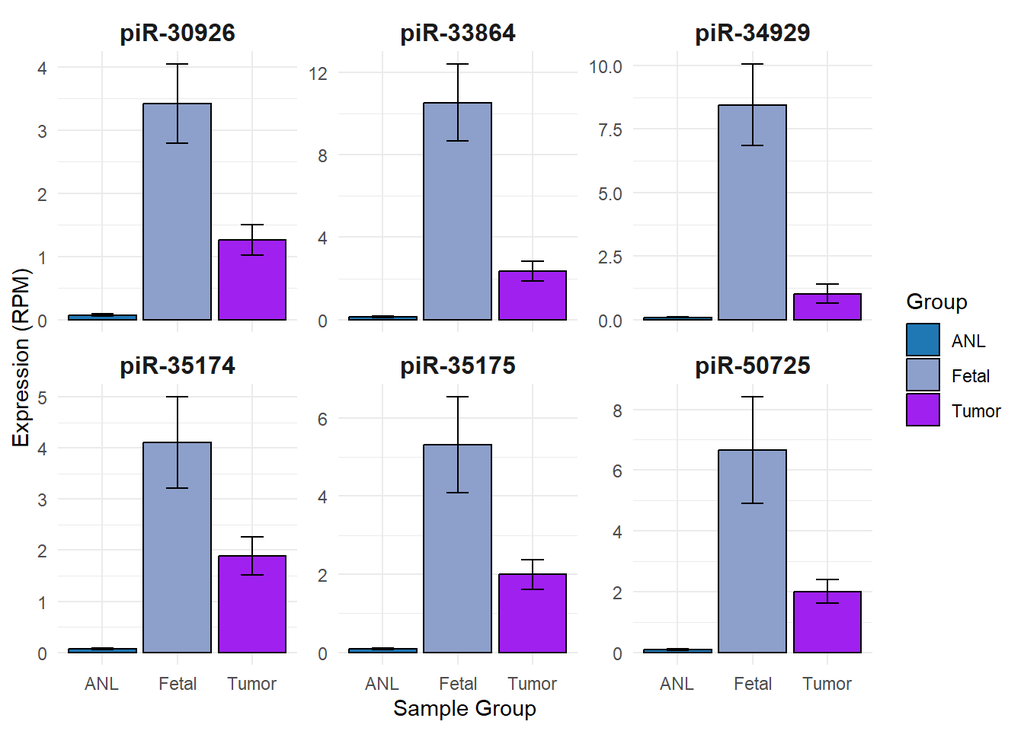

```r
# Define selected piRNAs for plotting
# List of selected piRNAs
selected_piRNAs_2 <- c("piR-35174",
                     "piR-35175",
                     "piR-50725",
                     "piR-30926",
                     "piR-33864",
                     "piR-34929")


# Define y-axis limits for each piRNA
y_limits <- list(
  "piR-35174" = c(0, 40),
  "piR-35175" = c(0, 50),
  "piR-50725" = c(0, 50),
  "piR-30926" = c(0, 40),
  "piR-33864" = c(0, 50),
  "piR-34929" = c(0, 50)

)

# Convert rownames to a column
All_couns_BCCA_Michelle_new <- tibble::rownames_to_column(All_couns_BCCA_Michelle, var = "piRNA")

## column name to character
colnames(All_couns_BCCA_Michelle_new) <- make.names(colnames(All_couns_BCCA_Michelle_new), unique = TRUE)

# Define color scheme
group_colors <- c("ANL" = "#1f77b4", "Tumor" = "purple", "Fetal" = "#8da0cb")


# Reshape data from wide to long format
long_data <- pivot_longer(All_couns_BCCA_Michelle_new,
                          cols = -piRNA,
                          names_to = "Sample",
                          values_to = "Expression")

# Extract sample group information
long_data <- long_data %>%
  mutate(Group = case_when(
    grepl("^Fetal_", Sample) ~ "Fetal",
    grepl("^ANL_", Sample) ~ "ANL",
    grepl("^Tumor_", Sample) ~ "Tumor",
    TRUE ~ "Other"
  ))

# Remove everything before and including "|"
long_data$piRNA <- sub(".*\\|", "", long_data$piRNA)

# Create a combined bar plot with facets
p3 <- ggplot(long_data %>% filter(piRNA %in% selected_piRNAs_2), aes(x = Group, y = Expression, fill = Group)) +
  stat_summary(fun = mean, geom = "bar", position = "dodge", color = "black") +  # Bar plot with mean values
  stat_summary(fun.data = mean_se, geom = "errorbar", width = 0.3, position = position_dodge(0.9)) +  # Error bars (SE)
  theme_minimal() +
  labs(x = "Sample Group", y = "Expression (RPM)") +
  scale_fill_manual(values = group_colors) +
  facet_wrap(~ piRNA, scales = "free_y") +  # Separate facets, independent y-axis limits
  theme(
    plot.title = element_text(size = 14, face = "bold"),
    strip.text = element_text(size = 12, face = "bold")  # Adjust facet labels
  )

## view
p3
```